# skyscapeR: from field measurements to skyscape analysis

Fabio Silva

This vignette walks through a skyscape analysis using field measurements. For installation instructions, see the [package README](https://github.com/stonexsky/skyscapeR/blob/development-2.0/README.md). For the algorithms, assumptions and validation results behind each function, see the [technical manual](https://stonexsky.github.io/skyscapeR/manual/).

This workflow starts with a measured axis at each site. Its **azimuth** is its bearing clockwise from north. The **horizon altitude** is the vertical angle to the skyline in that direction. Together with the site latitude these determine **declination**, the angular distance north or south of the celestial equator. We first calculate it from field measurements, then investigate one Maltese doorway and finally compare a group of entrances.

For help with any package function and its parameters, type `?` followed by its name in the R console, for example `?az2dec`.

# 1. Data input

## Import your observations

Give each site one row in your spreadsheet. Record one compass bearing along the axis, looking outwards, and the horizon altitude in the same direction. For the two illustrative sites used here, the worksheet is called `Compass`. Replace the path below with the path on your computer.

```r
library(skyscapeR)
survey <- readxl::read_excel("/Users/yourname/Research/field-survey.xlsx", sheet = "Compass")
```

```r
survey
```

```
#> # A tibble: 2 × 7
#>   id     survey_date         latitude longitude elevation_m mag_az_deg
#>   <chr>  <dttm>                 <dbl>     <dbl>       <dbl>      <dbl>
#> 1 Site A 2026-08-28 00:00:00     51.2     -1.83         105       84.5
#> 2 Site B 2026-08-28 00:00:00     51.2     -1.77         126       96.5
#> # ℹ 1 more variable: horizon_alt_deg <dbl>
```

Use `id` for the site name and `survey_date` for the date of the observation. Enter latitude and longitude in decimal degrees (south and west negative), site elevation in metres, and bearing and horizon altitude in degrees. Keep the measured bearing in its original column.

## Reduce compass readings to true azimuth

The package uses the International Geomagnetic Reference Field (IGRF-14), evaluated by oce for the site coordinates and survey date. Magnetic north changes with place and time. Use the date the compass was read. `reduct.compass()` adds the local magnetic declination to each bearing. Passing the locations and dates in worksheet order keeps each correction with its observation.

```r
locations <- as.matrix(survey[c("latitude", "longitude", "elevation_m")])
compass <- reduct.compass(loc = locations, mag.az = survey$mag_az_deg,
                          date = as.Date(survey$survey_date), ID = survey$id)
compass[c("ID", "Magnetic.Azimuth", "Mag.Dec", "True.Azimuth")]
```

```
#>       ID Magnetic.Azimuth   Mag.Dec True.Azimuth
#> 1 Site A             84.5 0.6373595         85.1
#> 2 Site B             96.5 0.6535282         97.2
```

`Mag.Dec` is the correction between magnetic and true north, in degrees east. For a manual reduction, calculate magnetic declination with `mag.dec(locations, as.Date(survey$survey_date))`, then add it to the magnetic bearing and wrap the result with `%% 360`. Alternatively pass an independently known correction as `magdec` to `reduct.compass()`. If your spreadsheet already records true azimuths, use that column directly in the next step.

## Reduce a theodolite survey with a solar sight

For field instructions on the sun-sight method, see the survey appendix in Clive Ruggles (1999), *Astronomy in Prehistoric Britain and Ireland*. A theodolite’s horizontal circle can have an arbitrary zero. In this alternative to the compass workflow, the surveyor recorded the circle reading to the Sun’s right limb and the local time of that sight. `reduct.theodolite()` uses the predicted azimuth of that limb to orient every structural reading made with the same circle setting. `ten()` converts the recorded degrees, minutes and seconds to decimal degrees.

The solar sight and later celestial examples need Swiss Ephemeris files covering the observation date. Install `swephRdata` and restart R, or set `SE_EPHE_PATH` to an existing ephemeris directory before loading skyscapeR.

```r
install.packages("swephRdata", repos = "https://rstub.r-universe.dev", type = "source")
```

```r
library(skyscapeR)
site_location <- c(51.18, -1.83, 105)
theo <- reduct.theodolite(loc = site_location, az = c(298.40, 302.35),
                          date = "2016/02/20", time = "11:07:17",
                          tz = "Europe/London", az.sun = ten(327, 29, 50),
                          limb = "right")
theo$Altitude <- c(2, 5)  # Horizon altitudes measured along the two sightlines
theo[c("Uncorrected.Azimuth", "Sun.Az", "True.Azimuth", "Altitude")]
```

```
#>   Uncorrected.Azimuth Sun.Az True.Azimuth Altitude
#> 1              298.40 160.09     130.9928        2
#> 2              302.35 160.09     134.9428        5
```

`Sun.Az` is the calculated solar reference bearing. To calculate it separately, use `sunAz()`.

## Convert each sightline to celestial declination

Carry each true azimuth forward with the latitude of the site and the measured altitude of the horizon along that sightline. For the compass sites the altitude is in the original worksheet.

```r
survey$true_az_deg <- compass$True.Azimuth %% 360
survey$dec_deg <- az2dec(survey$true_az_deg, loc = survey$latitude,
                         alt = survey$horizon_alt_deg)
survey[c("id", "true_az_deg", "horizon_alt_deg", "dec_deg")]
```

```
#> # A tibble: 2 × 4
#>   id     true_az_deg horizon_alt_deg dec_deg
#>   <chr>        <dbl>           <dbl>   <dbl>
#> 1 Site A        85.1             1.2     3.7
#> 2 Site B        97.2             3.4    -2
```

For the theodolite sightlines the reduced bearings and skyline heights are already together in `theo`.

```r
theo$Declination <- az2dec(theo$True.Azimuth, loc = theo$Latitude, alt = theo$Altitude)
theo[c("True.Azimuth", "Altitude", "Declination")]
```

```
#>   True.Azimuth Altitude Declination
#> 1     130.9928        2   -22.80645
#> 2     134.9428        5   -22.05407
```

## Which targets fit the measurement?

Search within 2° of the first site’s declination over a 200-year interval, from 3400 to 3200 BCE. Inspect the stellar candidates returned for that measurement.

```r
candidates <- findTargets(survey$dec_deg[1] + c(-2, 2), c("3400 BC", "3200 BC"))
```

```
#> Returning geocentric declination because no site was supplied.
```

```r
candidates$stellar
```

```
#>        name identifier  magV min.dec max.dec
#> 1   Procyon    alf CMi 0.370    1.57    2.30
#> 2    Alhena    gam Gem 1.920    2.88    3.89
#> 3 Alpheratz    alf And 2.060    4.68    5.20
#> 4  Dschubba    del Sco 2.320    2.51    3.63
#> 5     Sabik    eta Oph 2.420    4.58    5.71
#> 6            eta Oph A 2.463    4.70    5.83
#> 7     Acrab    bet Sco 2.500    4.97    6.09
```

# 2. Single site analysis

## The doorway at Mnajdra South

What celestial objects could be seen through the doorway of Mnajdra South? Start with its position and the true bearings of its two edges, surveyed by Tore Lomsdalen and published by [Silva and Lomsdalen (2025)](https://doi.org/10.1007/s12520-025-02208-4).

```r
door <- malta_entrances[1, ]
door[, c("Name", "Latitude", "Longitude", "Az L", "Az R")]
```

```
#> # A tibble: 1 × 5
#>   Name          Latitude Longitude `Az L` `Az R`
#>   <chr>            <dbl>     <dbl>  <dbl>  <dbl>
#> 1 Mnajdra South     35.8      14.4   90.9   99.1
```

```r
edges <- c(door[["Az L"]], door[["Az R"]])
door_frame <- c(edges[1], mean(edges), edges[2])
```

## Importing site horizons

If you surveyed the horizon in situ, import your observations as pairs of true azimuth and angular altitude in degrees. Supply the location of the instrument, including elevation in metres. These examples illustrate alternatives using your own files.

```r
profile <- read.csv("/Users/yourname/Research/surveyed-horizon.csv")
survey_location <- c(51.18, -1.83, 105)  # latitude, longitude, elevation in metres
surveyed <- createHor(az = profile$azimuth, alt = profile$altitude,
                      loc = survey_location)
plot(surveyed)
```

With a panoramic photograph, `importPanorama()` detects the skyline at the boundary between the transparent sky and the foreground. Use measured bearings and altitudes of identifiable landmarks to calibrate the image.

```r
photo <- importPanorama("doorway-east.png", loc = survey_location,
                        az.lim = c(75, 115), alt.lim = c(-5, 10), calibrate = TRUE)
plot(photo, show.skyline = TRUE)
```

A digital terrain model offers another way to reconstruct the horizon. **HeyWhatsThat** can generate a profile online from the site’s coordinates. Here the observer stands 1.6 m above the ground.

```r
hwt <- createHWT(lat = door$Latitude, lon = door$Longitude,
                 elevation = 1.6, name = "Mnajdra South")
```

Alternatively, export a **Horizon for Stellarium** ZIP from PeakFinder and read it with `importPeakFinder()`. A silhouettes SVG exported from the same viewpoint adds foreground ridge detail.

```r
pf <- importPeakFinder("landscape.zip", svg = "panorama.svg")
```

A local elevation raster gives control over the resolution, search distance and observer height. A finer DEM can resolve ridges smoothed away in a coarser one, provided it covers the terrain out to the visible skyline. With `terra` and `png` installed, `createHor()` can also render the terrain panorama.

```r
terrain <- createHor(dem = "survey-dem.tif", loc = c(door$Latitude, door$Longitude),
                     eye.height = 1.6, max.distance = 10000, image.dir = tempdir())
plot(terrain)
```

You can send any of these horizons to Stellarium with `exportStellarium()`. For Mnajdra South a horizon generated from a **5 m DEM** is already available with the published data. Its row index matches the entrance table. Read the skyline heights at the doorway edges and convert them to declinations.

```r
hor <- malta_horizons[[1]]
hor2alt(hor, edges)
```

```
#> [1] 4.40 3.45
```

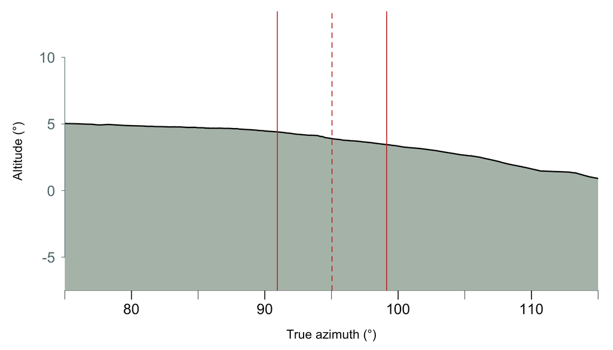

```r
plot(hor, xrange = c(75, 115))
abline(v = door_frame, col = "firebrick", lty = c(1, 2, 1))
```

```r
door_dec <- az2dec(edges, loc = hor)
```

## Which objects fit the doorway?

Screen the entrance across the Ġgantija phase, 3400–3100 BCE. Read both the solar and stellar candidates before selecting one to investigate.

```r
period <- c("3400 BC", "3100 BC")
targets <- findTargets(range(door_dec), period)
```

```
#> Returning geocentric declination because no site was supplied.
```

```r
targets$solar
```

```
#>                   name min.dec max.dec          date1          date2
#> 1 astronomical equinox    0.00    0.00         22 Mar         21 Sep
#> 2          sunrise/set   -5.48    1.71 7 Mar - 26 Mar 17 Sep - 5 Oct
```

```r
targets$stellar
```

```
#>       name identifier magV min.dec max.dec
#> 1  Procyon    alf CMi 0.37    1.57    2.65
#> 2  Antares    alf Sco 0.91   -3.31   -1.61
#> 3 Pleiades       M 45 1.60   -2.63   -0.97
#> 4  Alphard    alf Hya 1.97    0.21    0.62
#> 5    Hamal    alf Ari 2.01   -4.84   -3.48
#> 6     Enif    eps Peg 2.39   -1.29   -1.00
#> 7   Markab    alf Peg 2.48   -4.09   -3.79
```

## Equinoctial sunrise

Zero declination falls within the opening. For a worked year near the middle of the phase, the spring equinox falls on 17 April 3250 BCE in the proleptic Julian calendar. Find when the Sun’s centre crosses the terrain skyline. Compare its track at the sunrise declination (solid orange) with the equinox reference (dotted blue).

```r
year <- "3250 BC"
sun <- riseset(hor, date = "3250 BC/04/17", obj = "sun",
               calendar = "J", timezone = "UTC")$rise
sun
```

```
#>          date     time azimuth declination
#> 1 -3249/04/17 05:24:42 93.0919  -0.1716493
```

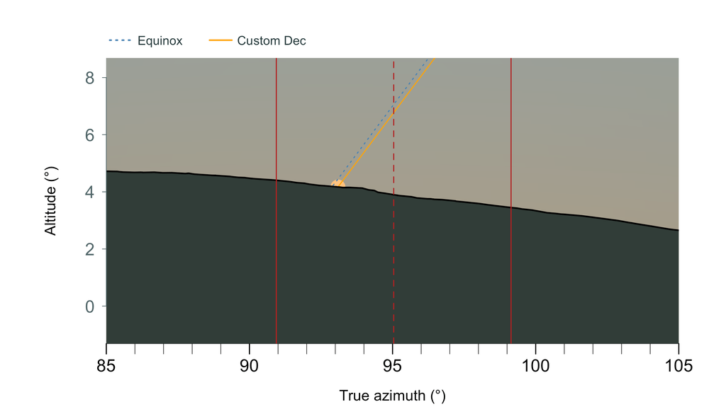

```r
sky <- sketchSky(hor, time = paste(sun$date, sun$time), calendar = "J", timezone = "UTC")
equinox <- skyObject("Equinox", year = year, loc = hor, col = "steelblue", lty = 3)
sunrise_track <- skyObject(sun$declination, year = year, loc = hor, col = "orange")
plot(hor, sky = sky, obj = list(equinox, sunrise_track), xrange = c(85, 105))
abline(v = door_frame, col = "firebrick", lty = c(1, 2, 1))
```

At local sunrise (05:25 UT), the Sun still has declination −0.172°. It reaches the equinox later that day, around 16:06 UT. At the rising bearing the equinox reference therefore passes 0.28° above the disc centre. The orange track through the centre uses the declination at sunrise. Compare the rising bearing with the two edges and the centre. These correspond to different claims about what someone standing inside the temple could observe.

## The heliacal rising of the Pleiades

[Ventura, Foderà Serio and Hoskin (1993), *Possible Tally Stones at Mnajdra, Malta*](https://www.um.edu.mt/library/oar/handle/123456789/12032), proposed the rising Pleiades as a candidate for this temple. Select the cluster, catalogue entry `M 45`, from the shortlist. First model its seasons of visibility, then extract the Julian date of heliacal rising.

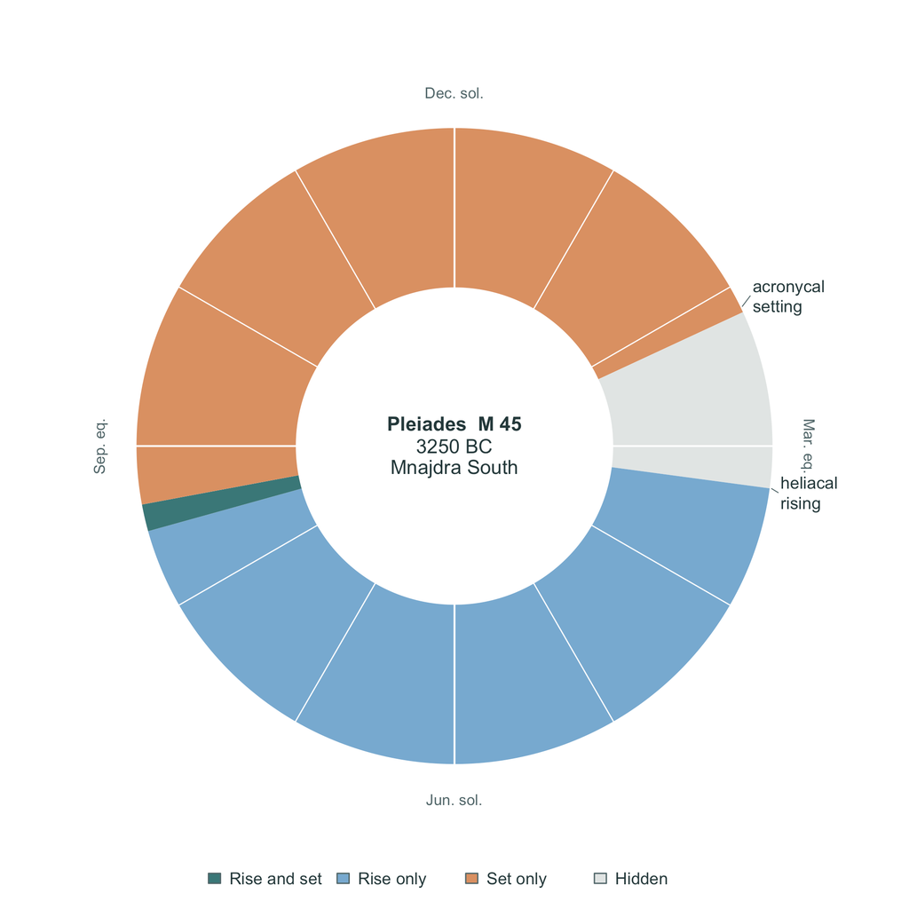

```r
phases <- star.phases("M 45", year, hor)
plot(phases)
```

```r
events <- phases$metadata$events
hr_date <- events$date.julian[events$event == "heliacal rising"]
hr_date
```

```
#> [1] "-3249/04/26"
```

The centre identifies the star, epoch and site. Read the solstice and equinox labels outside the rim, clockwise from December solstice. The white dividers mark twelve equal months of 30° in solar longitude. The Pleiades’ acronycal setting and heliacal rising are named beside the rim, with a short line to each event day. In the linear view, look just above the strip for heliacal rising and just below it for acronycal setting. Use `show.grid = FALSE` in either layout to hide the month dividers.

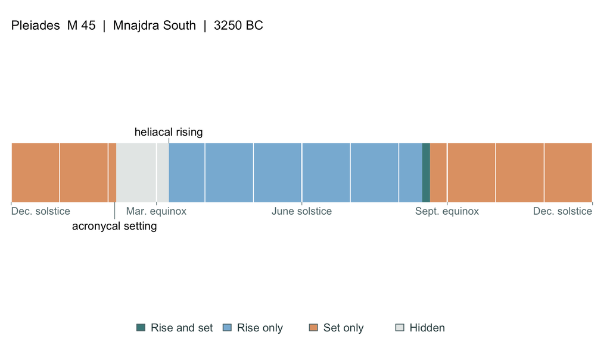

```r
plot(phases, layout = "linear")
```

Allow roughly a week around the predicted heliacal rising when looking for the first visible morning. The daily phase calculation and the twilight sketch estimate visibility differently. See `?star.phases` for the comparison behind this rule of thumb. For the illustration, move five calendar days beyond the prediction, calculate that morning’s skyline crossing, then allow five minutes for the cluster to climb into the opening. The five-day offset selects an illustrative morning. The predicted event date remains the one printed above. The label points to the cluster centre. The natural sketch draws catalogue stars at their positions and assigns the remaining cluster light to a diffuse patch.

```r
predicted_jd <- time2jd(hr_date, calendar = "J", timezone = "UTC")
rise <- riseset(hor, jd = predicted_jd + 5, obj = "M 45", calendar = "J", timezone = "UTC")$rise
rise
```

```
#>          date     time  azimuth declination
#> 1 -3249/05/01 03:43:12 94.92529   -1.803221
```

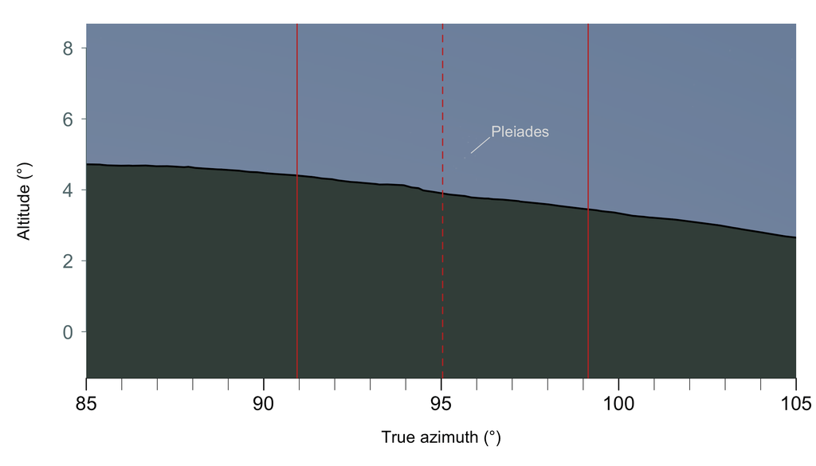

```r
rise_jd <- time2jd(paste(rise$date, rise$time), timezone = "UTC", calendar = "J")
sky <- sketchSky(hor, jd = rise_jd + 5 / 1440)
plot(hor, sky = sky, xrange = c(85, 105))
abline(v = door_frame, col = "firebrick", lty = c(1, 2, 1))
target <- as.numeric(sky$clusters[sky$clusters$identifier == "M 45", c("az", "alt")])
segments(target[1] + 0.18, target[2] + 0.14,
         target[1] + 0.70, target[2] + 0.58, col = "grey85", lwd = 0.7)
text(target[1] + 0.75, target[2] + 0.60, "Pleiades", adj = c(0, 0), col = "grey85", cex = 0.78)
```

The illustrated morning is 1 May 3250 BCE. Look near azimuth 95.7° and altitude 4.9°, just above the skyline. At that instant the Sun is 10.9° below the horizon, compared with 8.6° at the equivalent point on the predicted morning. The solid lines bracket the doorway and the dashed line marks its centre. The phase calculation uses the Pleiades’ combined magnitude of 1.60. To examine an individual star, repeat the calculation for Alcyone (magnitude 2.87). Use the same five-day offset from Alcyone’s own prediction and view it sixteen minutes after its skyline crossing.

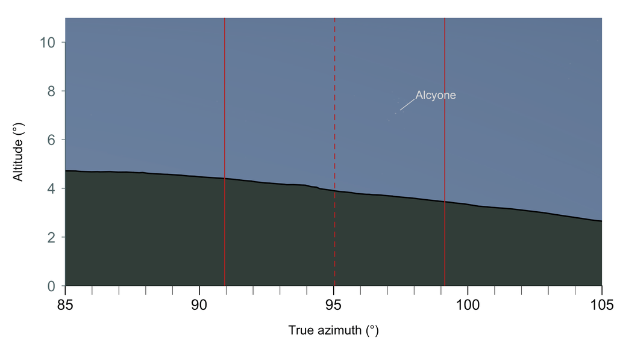

```r
alcyone <- star.phases("Alcyone", year, hor)
events <- alcyone$metadata$events
date <- events$date.julian[events$event == "heliacal rising"]
alcyone_day <- time2jd(date, calendar = "J", timezone = "UTC")
alcyone_rise <- riseset(hor, jd = alcyone_day + 5, obj = "Alcyone", calendar = "J", timezone = "UTC")$rise
jd <- time2jd(paste(alcyone_rise$date, alcyone_rise$time), timezone = "UTC", calendar = "J")
sky <- sketchSky(hor, jd = jd + 16 / 1440)
plot(hor, sky = sky, xrange = c(85, 105), yrange = c(0, 11))
abline(v = door_frame, col = "firebrick", lty = c(1, 2, 1))
target <- as.numeric(sky$stars["eta Tau", c("az", "alt")])
segments(target[1] + 0.18, target[2] + 0.14,
         target[1] + 0.70, target[2] + 0.58, col = "grey85", lwd = 0.7)
text(target[1] + 0.75, target[2] + 0.60, "Alcyone", adj = c(0, 0), col = "grey85", cex = 0.78)
```

### Watch the cluster rise later in the season

Return 60 days after heliacal rising and calculate the new rising time. The two solid lines mark the edges of the doorway.

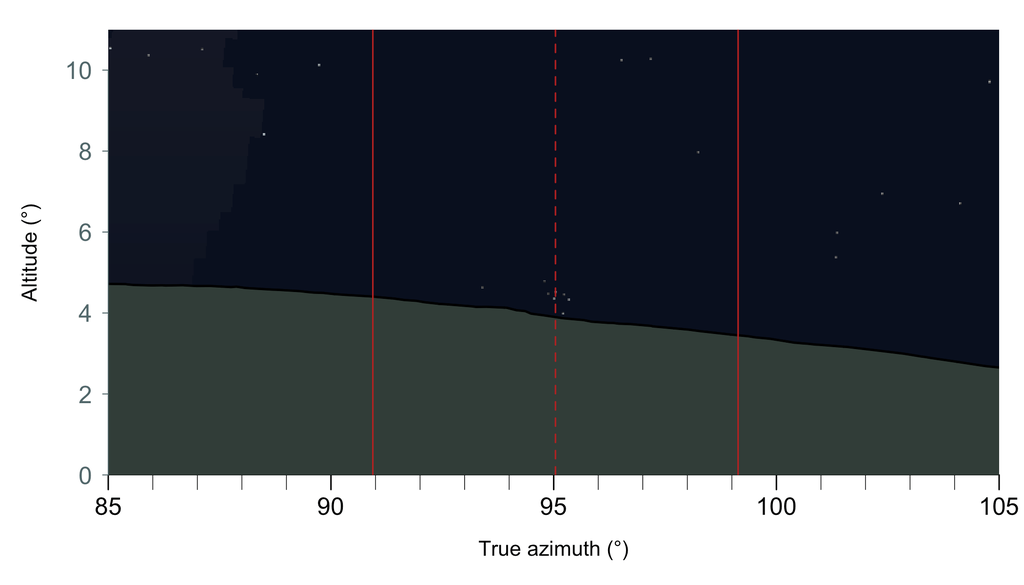

```r
later <- riseset(hor, jd = predicted_jd + 60, obj = "M 45", calendar = "J", timezone = "UTC")$rise
sky <- sketchSky(hor, time = paste(later$date, later$time), calendar = "J", timezone = "UTC")
sector <- c(85, 105)
plot(hor, sky = sky, xrange = sector, yrange = c(0, 11))
abline(v = door_frame, col = "firebrick", lty = c(1, 2, 1))
```

Advance the same view by ten minutes to see the individual members clearing the ridge.

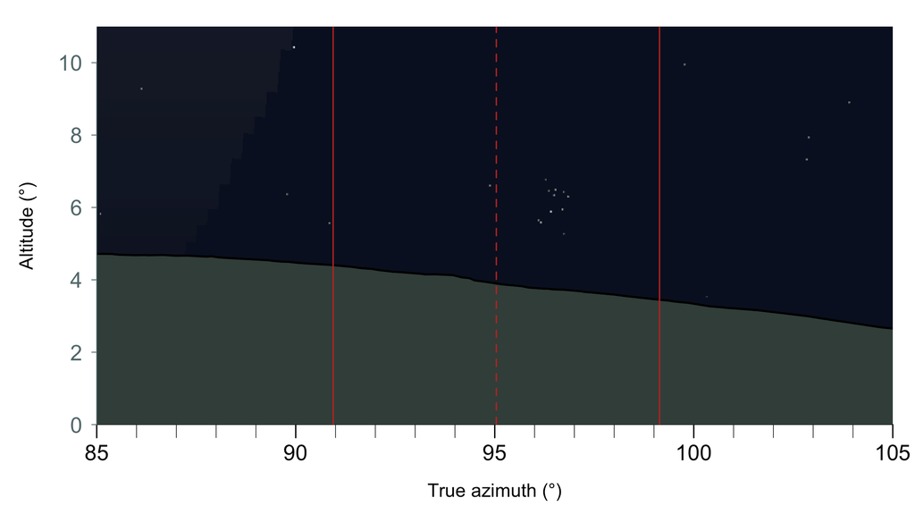

```r
sky <- skyStep(hor, sky, minutes = 10, xrange = sector, yrange = c(0, 11))
abline(v = door_frame, col = "firebrick", lty = c(1, 2, 1))
```

# 3. Multiple site analysis

## Start with the Ġgantija entrance bearings

Select the Ġgantija phase in both datasets with the same row indices. First look at the central directions on a compass with `plotAzimuth()`. Then compare the full width of each opening with `plotBars()`. The bar extends from the measured left edge to the right edge.

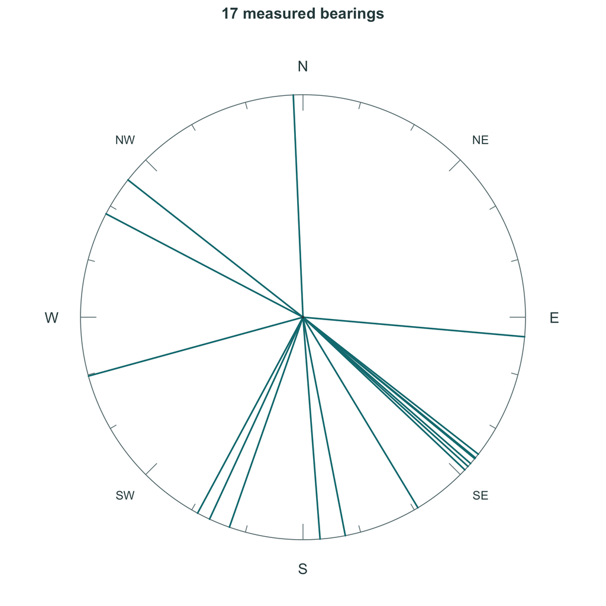

```r
rows <- which(malta_entrances$Phase == "Ggantija")
sites <- malta_entrances[rows, ]
profiles <- malta_horizons[rows]
width <- (sites[["Az R"]] - sites[["Az L"]]) %% 360
centre <- (sites[["Az L"]] + width / 2) %% 360
plotAzimuth(centre)
```

For a level-horizon comparison, place the solstice lines outside the compass at the Mnajdra South latitude. The two-line labels identify the target and the event. Each label stays outside even if you choose `obj.position = "inside"` for the lines.

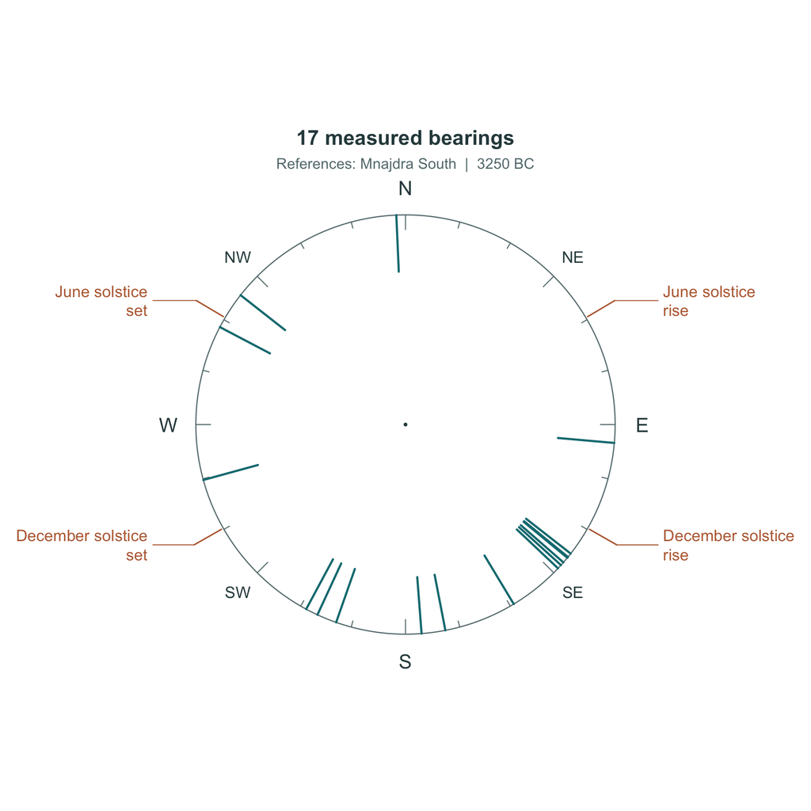

```r
solstices <- skyObject("solar extremes", year = year, loc = hor)
plotAzimuth(centre, obj = solstices, marks = "rim", obj.position = "outside")
```

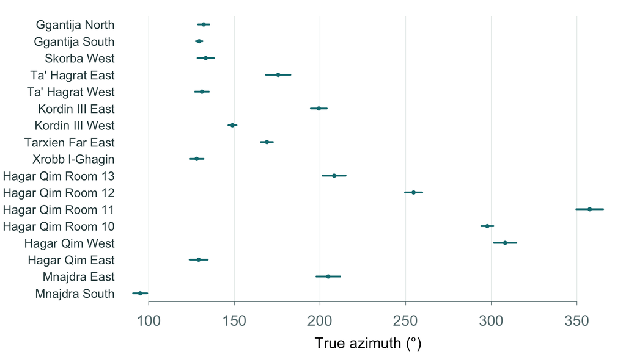

```r
plotBars(centre, unc = width / 2, names = sites$Name, unit = "Azimuth")
```

## Give each opening a distribution

For the method and its treatment of uncertainty, see [Silva (2020)](https://doi.org/10.1016/j.jas.2020.105138). Here each bearing inside an opening is equally likely. Its half-width sets the uncertainty of a uniform distribution. Convert each entrance across its own skyline, then sum the declination distributions.

```r
bearings <- az.pdf(pdf = "uniform", az = centre, unc = width / 2, name = sites$Name)
```

```
#> Using uniform azimuth uncertainties.
```

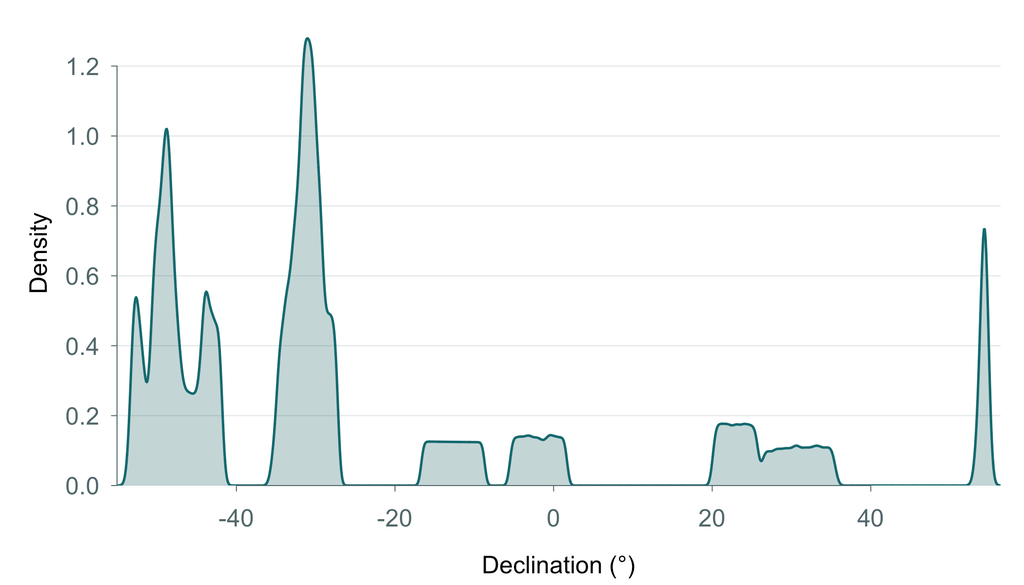

```r
decs <- coordtrans(bearings, profiles)
plot(spd(decs))
```

Inspect the transformation for Mnajdra South. The left marginal gives the original entrance bearings, the middle panel maps them across the measured skyline, and the lower marginal shows the resulting declination density. At 68% the readout lists two disjoint highest-density intervals.

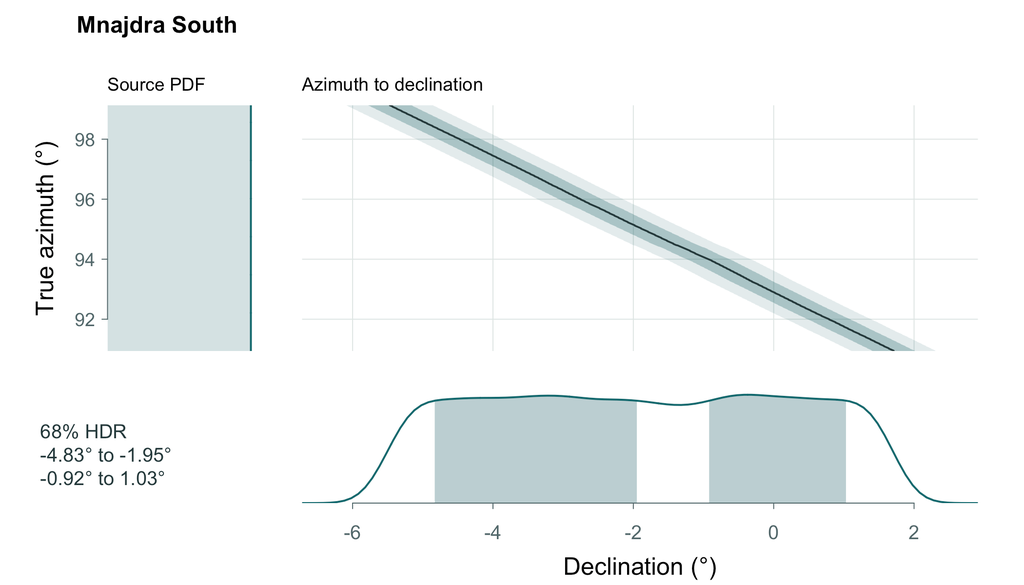

```r
plot(decs, index = 1, az = bearings, hor = profiles, hdr = 0.68)
```

## Test random orientations

Would random bearings at these same sites produce concentrations as strong as the observed ones? Keep the measured widths and site profiles in the test. The following call reproduces the 500 simulations used here.

```r
set.seed(42)
fit <- randomTest(decs, az = bearings, hor = profiles, nsims = 500)
```

The result is bundled so that building the vignette does not repeat the simulation.

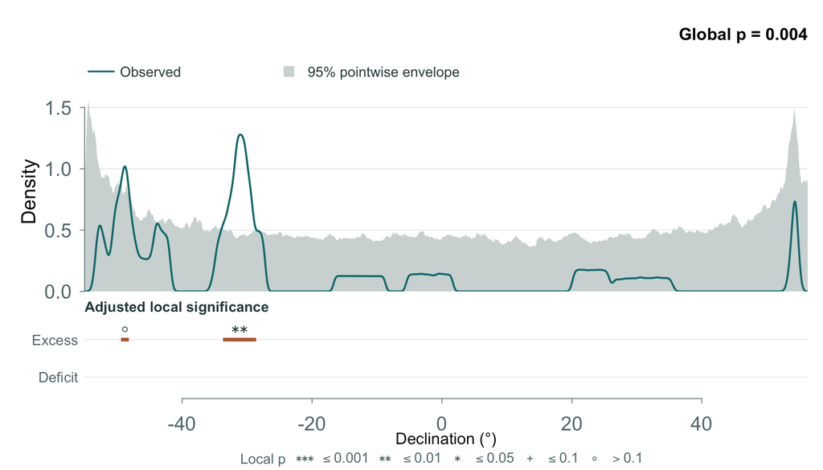

```r
fit <- readRDS(system.file("extdata", "ggantija-random-500.rds", package = "skyscapeR"))
plot(fit, show.local = TRUE)
```

```r
fit$metadata$local.pval
```

```
#>   type start   end     p.value
#> 1    + -49.4 -48.2 0.556886228
#> 2    + -33.7 -28.6 0.003992016
```

The global p-value is 0.004. The lower panel has a row for excesses and a row for deficits. The excess at −33.7° to −28.6° has adjusted p = 0.004 and carries two stars. The smaller excess near −49° carries an open circle (adjusted p = 0.557). The deficit row is empty. A + denotes 0.05 < adjusted p ≤ 0.10.

## Exploring celestial candidates

That peak warrants looking for possible celestial explanations. Search the locally significant interval across the dates of the Ġgantija phase.

```r
bands <- fit$metadata$local.pval
peak <- subset(bands, type == "+" & p.value < 0.05)
candidates <- findTargets(c(peak$start, peak$end), period)
```

```
#> Returning geocentric declination because no site was supplied.
```

```r
candidates$stellar
```

```
#>               name identifier  magV min.dec max.dec
#> 1  Rigil Kentaurus    alf Cen -0.10  -34.85  -33.35
#> 2                   alf Cen A  0.01  -34.59  -33.07
#> 3            Hadar    bet Cen  0.58  -33.19  -31.80
#> 4           Mimosa    bet Cru  1.25  -33.56  -32.39
#> 5          Toliman  alf Cen B  1.33  -35.00  -33.51
#> 6           Gacrux    gam Cru  1.64  -31.18  -30.07
#> 7            Wezen    del CMa  1.84  -31.53  -30.55
#> 8           Mirzam    bet CMa  1.97  -29.63  -28.31
#> 9           Suhail    lam Vel  2.21  -32.15  -32.13
#> 10          Aludra    eta CMa  2.45  -32.10  -31.25
```

Several stars fit. For the archaeological and astronomical arguments for investigating Gacrux, see [Silva and Lomsdalen (2025)](https://doi.org/10.1007/s12520-025-02208-4). Overlay its declination range on the same test.

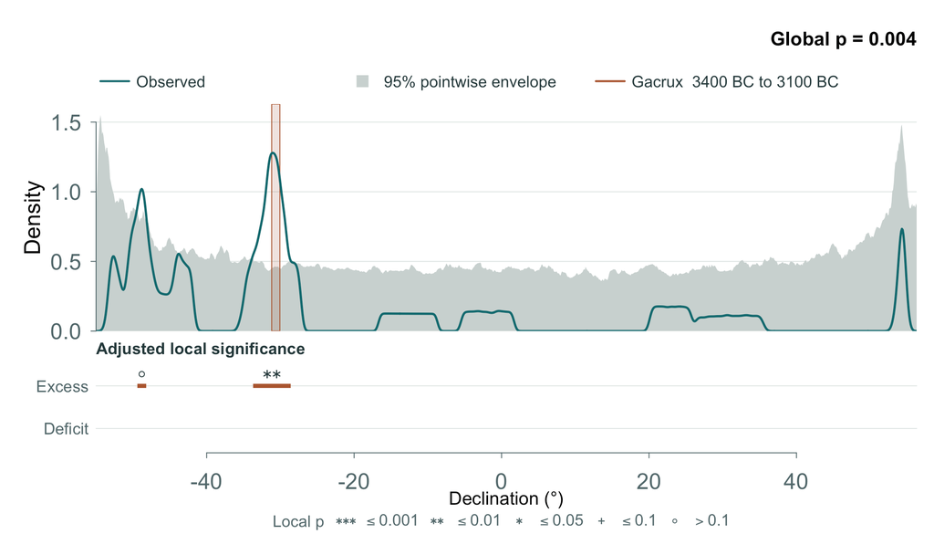

```r
gacrux <- skyObject("Gacrux", year = period)
plot(fit, obj = gacrux, show.local = TRUE)
```

Take Skorba West, one entrance in that band. Use its own horizon to find Gacrux’s heliacal rising date and crossing time. The vertical lines mark the two sides of this entrance.

```r
i <- which(sites$Name == "Skorba West")
site_hor <- profiles[[i]]
opening <- c(sites[["Az L"]][i], sites[["Az R"]][i])
g_phases <- star.phases("Gacrux", year, site_hor)
g_events <- g_phases$metadata$events
g_date <- g_events$date.julian[g_events$event == "heliacal rising"]
g_day <- time2jd(g_date, calendar = "J", timezone = "UTC")
g_rise <- riseset(site_hor, jd = g_day + 5, obj = "Gacrux",
                  calendar = "J", timezone = "UTC")$rise
g_rise
```

```
#>          date     time  azimuth declination
#> 1 -3249/10/17 03:33:11 129.9315   -30.61504
```

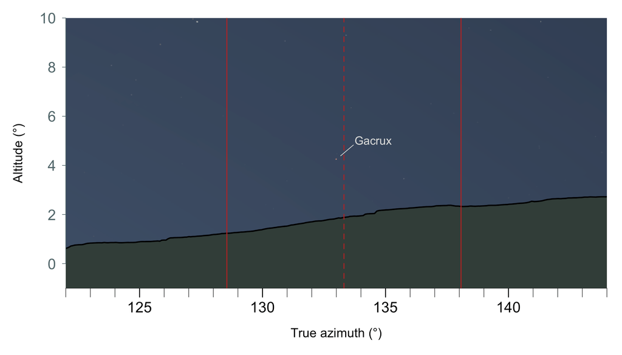

```r
g_jd <- time2jd(paste(g_rise$date, g_rise$time), timezone = "UTC", calendar = "J")
sky <- sketchSky(site_hor, jd = g_jd + 20 / 1440)
plot(site_hor, sky = sky, xrange = c(122, 144), yrange = c(-1, 10))
abline(v = c(opening[1], mean(opening), opening[2]), col = "firebrick", lty = c(1, 2, 1))
target <- as.numeric(sky$stars["gam Cru", c("az", "alt")])
segments(target[1] + 0.18, target[2] + 0.14,
         target[1] + 0.70, target[2] + 0.58, col = "grey85", lwd = 0.7)
text(target[1] + 0.75, target[2] + 0.60, "Gacrux", adj = c(0, 0), col = "grey85", cex = 0.78)
```

Here too the sketch uses the fifth morning after the predicted date, 17 October 3250 BCE. Look twenty minutes after the crossing, between the measured doorway edges at 128.55° and 138.07°.

To test a particular explanation, `modelTest()` accepts an expected distribution, including a separate one for each site. Silva and Lomsdalen compared the orientations with expectations based on slope aspect, shelter from prevailing winds and exposure to winter sunlight. Each hypothesis gives a different set of expected directions against which to judge the observed concentration.

# 4. Other tools

## Compare the three sky styles

Look high in the southeast from Mnajdra South at 20:00 UTC on 21 December 2026. Keep the time, horizon and field of view fixed. The Moon is 93% illuminated. Look just below and left of it for the Pleiades. At the Moon’s altitude of 76°, one degree of azimuth spans only about a quarter of a degree on the sky. This close view uses matching horizontal and vertical angular scales near the Moon so its gibbous outline is visible. The two publication styles show the stellar pattern on a white background. Publication colour uses spectral class for hue and magnitude for symbol size. The hot B-type Pleiades stars appear blue even when their symbols are small. Publication monochrome draws them in black.

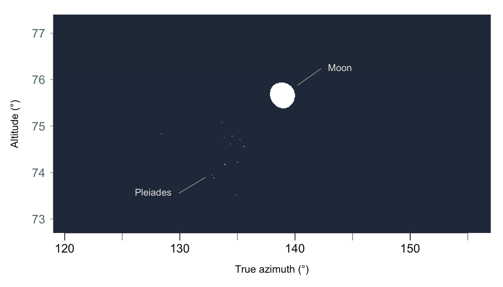

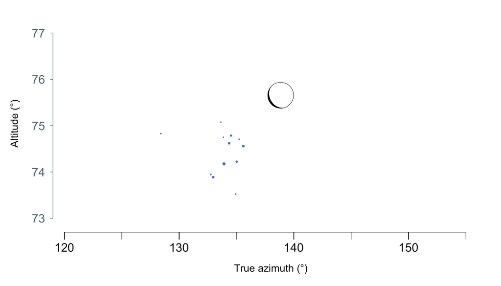

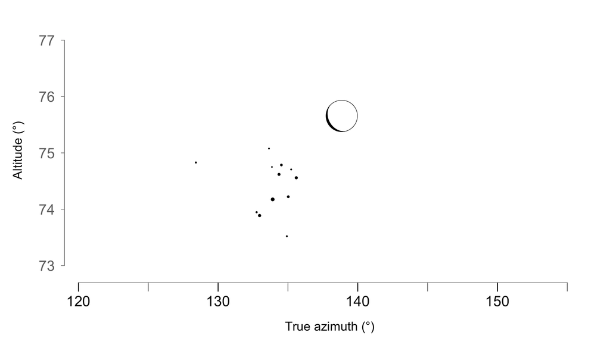

Publication monochrome

```r
moon_sector <- c(119, 157)
moon_heights <- c(72.7, 77.4)
when <- "2026/12/21 20:00"

natural <- sketchSky(hor, time = when, timezone = "UTC", style = "natural")
plot(hor, sky = natural, xrange = moon_sector, yrange = moon_heights)
cluster <- subset(natural$clusters, identifier == "M 45")
moon <- natural$bodies$moon
segments(cluster$az - 4, cluster$alt - 0.62, cluster$az - 1.7, cluster$alt - 0.28,
         col = "grey70", lwd = 0.7)
text(cluster$az - 4, cluster$alt - 0.62, "Pleiades", pos = 2, col = "grey85", cex = 0.8)
segments(moon[1] + 1.35, moon[2] + 0.22, moon[1] + 3.4, moon[2] + 0.58,
         col = "grey70", lwd = 0.7)
text(moon[1] + 3.4, moon[2] + 0.58, "Moon", pos = 4, col = "grey85", cex = 0.8)

colour <- sketchSky(hor, time = when, timezone = "UTC", style = "publication-colour")
plot(hor, sky = colour, xrange = moon_sector, yrange = moon_heights)

mono <- sketchSky(hor, time = when, timezone = "UTC", style = "publication-mono")
plot(hor, sky = mono, xrange = moon_sector, yrange = moon_heights)
```

## Compare stellar seasons

Keep the Mnajdra South skyline and visibility settings fixed. The centre identifies Aldebaran, its Bayer designation and the site. The three rings show the star at 4000, 3250 and 2000 BCE, from the outside inward. A leader connects each epoch to its own ring. The monthly divisions run across all three rings from December solstice, so you can follow changes in the start and duration of each season.

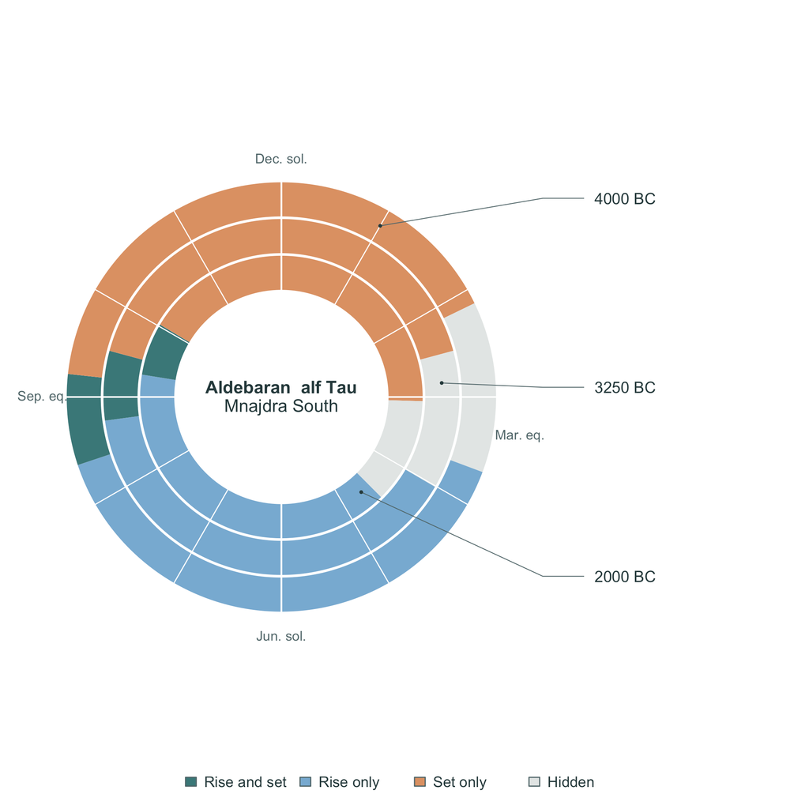

```r
ald <- lapply(c("4000 BC", "3250 BC", "2000 BC"),
              function(y) star.phases("Aldebaran", y, hor))
plot(ald[[1]], ald[-1])
```

Use `layout = "linear"` in the same call to compare the seasons as aligned strips. See `?plot.skyscapeR.starphases` for comparisons involving several stars.

## Compare constellation patterns

Use the publication colour style for both views. First draw the modern Western constellations over the eastern half of the sky.

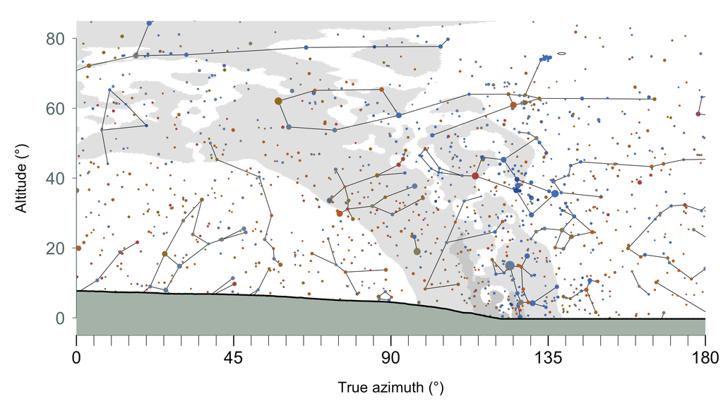

Modern Western constellations above the eastern horizon at Mnajdra South.

```r
sector <- c(0, 180)
heights <- c(-5, 85)
sky <- sketchSky(hor, time = when, timezone = "UTC", style = "publication-colour",
                 display = list(constellations = "modern"))
plot(hor, sky = sky, xrange = sector, yrange = heights)
```

Now draw the asterisms of the 28 Chinese lunar mansions over the same stars. Look for the same bright stars in both panels and follow the different lines that connect them.

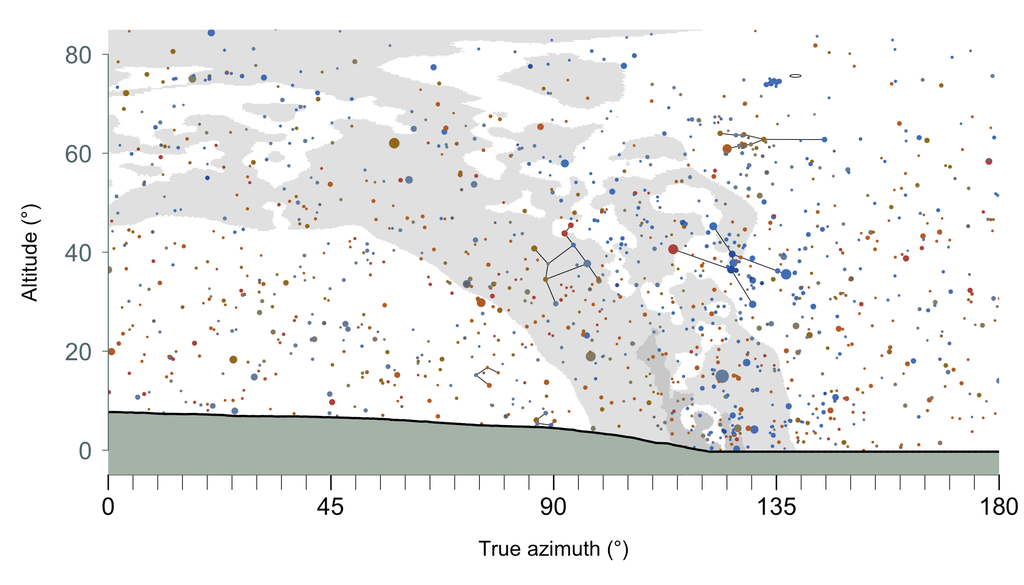

Chinese lunar-mansion asterisms visible in the same eastern sky.

```r
sky <- sketchSky(hor, time = when, timezone = "UTC", style = "publication-colour",
                 display = list(constellations = "chinese_mansions"))
plot(hor, sky = sky, xrange = sector, yrange = heights)
```

To select just two modern figures, use `constellations = c("Orion", "Taurus")`.

Select an individual figure with its stable identifier, such as `"CHN009"` for Horn. Use `subset(constellations, set == "chinese_mansions")` to browse the names and identifiers. See `?constellations` for sources, licences, historical context and stellar-data limitations.

To draw your own constellation lines, import a Stellarium **legacy** `constellationship.fab` file. Each row contains a figure ID, the segment count, and two Hipparcos numbers per segment. This is the legacy text format, not Stellarium’s newer JSON sky-culture format. See the [Stellarium User Guide](https://stellarium.org/guide/), “Adding Sky Cultures” in older editions, for the line-file guidelines.

```r
my_figures <- importConstellations("my-constellationship.fab")
# Subset rows here if only some figures should be drawn.
sky <- sketchSky(hor, time = "2026/12/21 20:00", timezone = "UTC",
                 display = list(constellations = my_figures))
plot(hor, sky = sky, xrange = sector)
abline(v = door_frame, col = "firebrick", lty = c(1, 2, 1))
```

The imported object stays in your script and can be saved with `saveRDS()`. It does not change the bundled constellation sets. `skyStep()` retains the custom selection. This imports line connections only; the endpoint stars must exist in the package’s stellar catalogue. It does not configure an external Stellarium installation. Credit the source and respect its sky-culture licence.

## Explore the Milky Way and reference circles

The Milky Way appears with the stars by default. Dark lanes and two brighter layers trace its structure; in a natural view, extinction dims the band towards the horizon. Use `display = list(milky.way = FALSE)` to hide the band, or `galactic.equator = TRUE` in the display list to add its reference circle. The planisphere uses `show.milky.way` and `show.galactic.equator`.

Look south from Mnajdra South on a July night. The first figure shows the natural band with the Moon hidden. Use the same place, time and field of view in the second figure to identify the Galactic equator, ecliptic and celestial equator against the band.

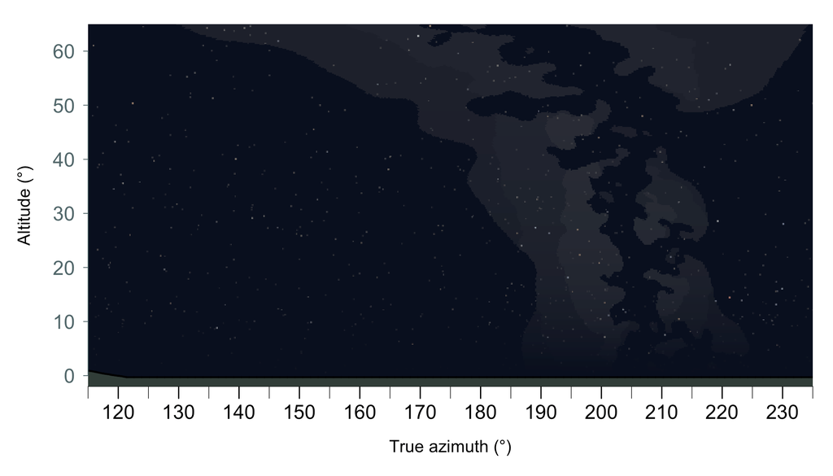

The summer Milky Way above the southern horizon at Mnajdra South, 15 July 2026 at 23:00 UTC.

```r
mw_time <- "2026/07/15 23:00"
mw <- sketchSky(hor, time = mw_time, timezone = "UTC",
                display = list(moon = FALSE))
plot(hor, sky = mw, xrange = c(115, 235), yrange = c(-2, 65))
```

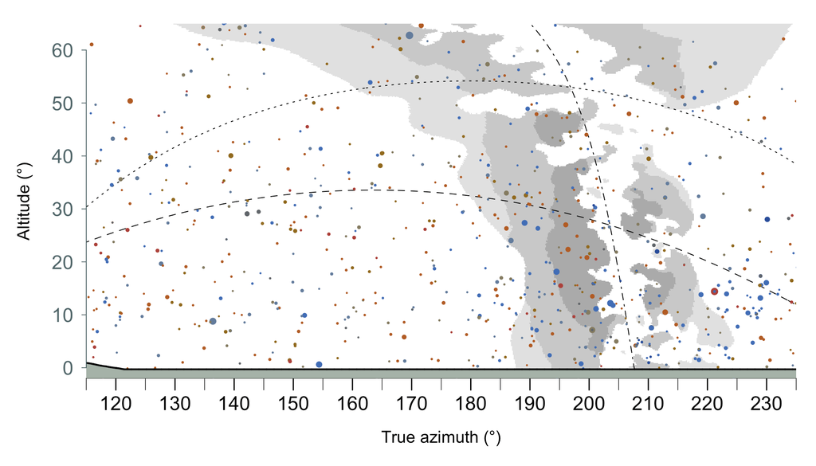

The same field in publication colour. The Galactic equator is dot-dashed, the ecliptic dashed and the celestial equator dotted.

```r
guides <- sketchSky(hor, time = mw_time, timezone = "UTC",
                    style = "publication-colour", display = list(moon = FALSE,
                    galactic.equator = TRUE, equator = TRUE, ecliptic = TRUE))
plot(hor, sky = guides, xrange = c(115, 235), yrange = c(-2, 65))
```

To see which features belong to the Milky Way, keep the same view and switch off just the band. Compare the stars and dark sky below with the natural view above.

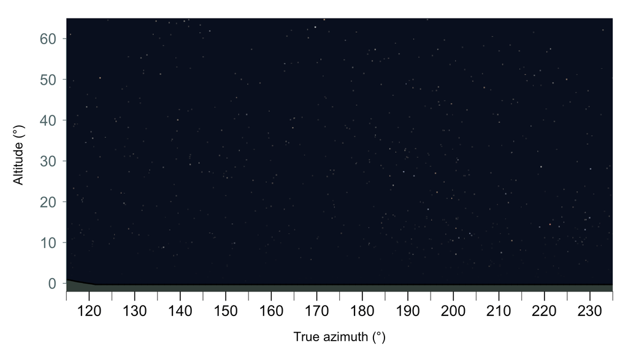

The same natural view with the Milky Way switched off; the stars and atmosphere are still drawn.

```r
without_band <- sketchSky(hor, time = mw_time, timezone = "UTC",
                          display = list(moon = FALSE, milky.way = FALSE))
plot(hor, sky = without_band, xrange = c(115, 235), yrange = c(-2, 65))
```

## Capture a sky from Stellarium

For a rendered background, enable Remote Control in Stellarium Desktop and follow the screenshot setup in `?stellariumSky`. A 4096-pixel capture is a starting point. Use a sketch when zooming beyond the available image detail.

```r
sky <- stellariumSky(hor, time = "2026/12/21 20:00", timezone = "UTC",
                    width = 4096, display = list(atmosphere = TRUE, cardinals = FALSE))
plot(hor, sky = sky, xrange = sector)
abline(v = door_frame, col = "firebrick", lty = c(1, 2, 1))
sky <- skyStep(hor, sky, minutes = -0.5, xrange = sector)
abline(v = door_frame, col = "firebrick", lty = c(1, 2, 1))
```

With either sky, assign each step to continue from the displayed time and repeat `xrange` to retain the sector. A sketch keeps its constellation selection. Stellarium takes a new screenshot. Redraw the doorway edges and centre after each step. Record the calendar and time zone alongside an archaeological reconstruction.

## Equinoctial full Moons and solstitial crescent crossovers

[Silva and Pimenta (2012)](https://doi.org/10.1177/002182861204300204) explore how the rising and setting positions of the Sun and Moon cross over. Two functions let us explore these events.

Which near-full Moon first meets the spring crossover condition? Inspect the paired lunar and solar observations returned by `EFM()`.

```r
full_moon <- EFM(year = 2026, loc = c(40, 0, 400), season = "spring", timezone = "UTC")
full_moon$Moon
```

```
#>   year       date     time  azimuth declination
#> 1 2026 2026/04/01 18:05:53 97.56414   -6.149152
```

```r
full_moon$Sun
```

```
#>   year       date     time  azimuth declination
#> 1 2026 2026/04/01 05:45:39 83.58084    4.553975
```

For the winter first-crescent crossover, compare the setting positions and inspect the visibility diagnostics.

```r
crescent <- CC(year = 2026, loc = c(40, 0, 400), season = "winter", crescent = "first",
               timezone = "UTC", simulation = "SIM1")
crescent$Moon
```

```
#>   year       date     time  azimuth declination      jd
#> 1 2026 2027/01/09 18:26:47 244.9829   -18.67155 2461415
```

```r
crescent$diagnostics[, c("status", "visibility.margin", "day.offset")]
```

```
#>   status visibility.margin day.offset
#> 1     ok          9.339496          0
```

## A planisphere for the site’s latitude

Place the bright stellar candidates in the wider sky for the same epoch. The Galactic equator provides a reference for the orientation of the Milky Way.

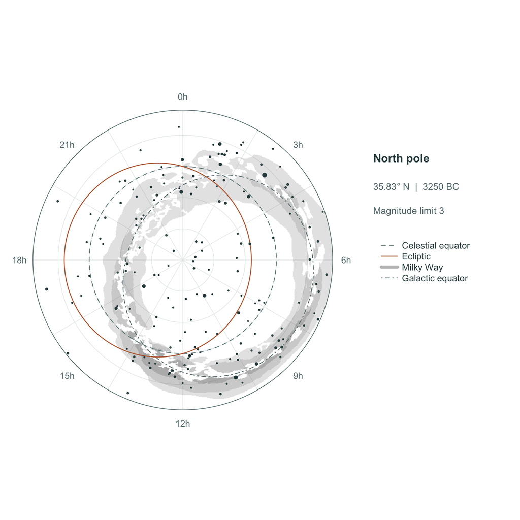

```r
planisphere(year, lat = door$Latitude, max.mag = 3, show.galactic.equator = TRUE)
```

Add the Chinese lunar-mansion asterisms to the same chart. The lines connect catalogue stars even when an endpoint is fainter than the magnitude limit; only the part within the site’s accessible sky is drawn. This shows their arrangement across the celestial sphere, rather than their visibility at a particular time of night.

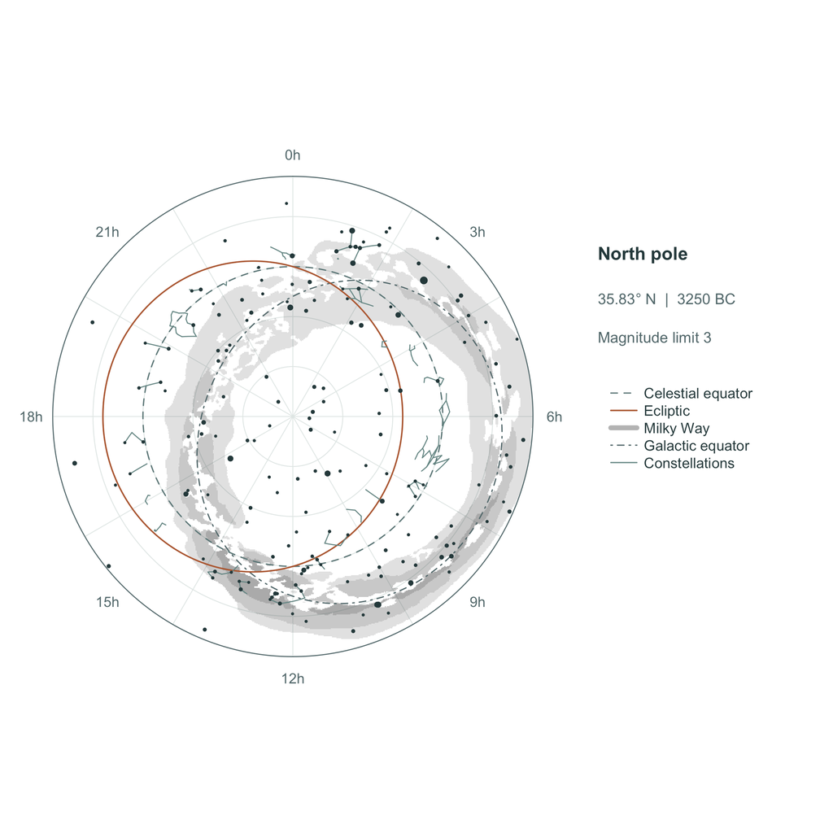

Chinese lunar-mansion asterisms on the planisphere for Mnajdra South’s latitude and the chosen epoch.

```r
planisphere(year, lat = door$Latitude, max.mag = 3,
            show.galactic.equator = TRUE, constellations = "chinese_mansions")
```

## Other questions about the sky

| What would you like to do? | Functions |
| --- | --- |
| Reduce compass and theodolite observations, or check a solar sight? | `reduct.compass()`, `mag.dec()`, `reduct.theodolite()`, `sunAz()`, `ten()` |
| Build, retrieve or import a skyline and find its height at a bearing? | `createHor()`, `createHWT()`, `downloadHWT()`, `importPeakFinder()`, `importPanorama()`, `hor2alt()` |
| Add a reconstructed feature, choose terrain colours, move a panorama or export a landscape? | `horFeature()`, `demPalettes()`, `relinkHor()`, `exportPanorama()`, `exportHor()`, `exportStellarium()` |
| Compare bearings and turn an opening or individual measurement into declination? | `plotAzimuth()`, `plotBars()`, `az2dec()`, `az.pdf()`, `dec.pdf()`, `coordtrans()` |
| Summarise the group and test an orientation hypothesis? | `spd()`, `hpdi()`, `randomTest()`, `modelTest()`, `pval2stars()`, `bernoulli.trial()` |
| Screen possible targets, retrieve a star, estimate its seasons or draw target bands? | `findTargets()`, `star()`, `star.phases()`, `skyObject()`, `sky.objects()` |
| Calculate a position, trace a daily path or time a skyline crossing? | `body.position()`, `orbit()`, `riseset()` |
| Sketch or capture a view, advance time, chart the sky or import a constellation? | `sketchSky()`, `stellariumSky()`, `skyStep()`, `planisphere()`, `importConstellations()` |
| Explore equinoxes, solstices, overhead passages and their calendar dates? | `eq()`, `spatial.equinox()`, `jS()`, `dS()`, `obliquity()`, `solar.date()`, `zenith()`, `antizenith()` |
| Find limiting declinations for this horizon, the Moon or the planets? | `hor2max.dec()`, `hor2min.dec()`, `nMjLX()`, `sMjLX()`, `nmnLX()`, `smnLX()`, `parallax.corr()`, `planet.extremes()` |
| Investigate lunar phases, equinoctial full Moons and solstitial crescent crossovers? | `moonphase()`, `EFM()`, `CC()` |
| Convert epochs, date labels or Julian days, or inspect session settings? | `astroYear()`, `BC.AD()`, `long.date()`, `timestring()`, `time2jd()`, `jd2time()`, `skyscapeR.vars()` |

# References

Ruggles, C. L. N. (1999). *Astronomy in Prehistoric Britain and Ireland*. Yale University Press.

Silva, F. (2020). A probabilistic framework and significance test for the analysis of structural orientations in skyscape archaeology. *Journal of Archaeological Science*, 118, 105138. [DOI](https://doi.org/10.1016/j.jas.2020.105138)

Silva, F. and Lomsdalen, T. (2025). ‘No easy way from the earth to the stars’: a new statistical approach to the orientation of the Maltese temples. *Archaeological and Anthropological Sciences*, 17, 96. [DOI](https://doi.org/10.1007/s12520-025-02208-4)

Silva, F. and Pimenta, F. (2012). The crossover of the Sun and the Moon. *Journal for the History of Astronomy*, 43(2), 191–208. [DOI](https://doi.org/10.1177/002182861204300204)

Ventura, F., Foderà Serio, G. and Hoskin, M. (1993). Possible tally stones at Mnajdra, Malta. *Journal for the History of Astronomy*, 24(3), 171–183. [University of Malta](https://www.um.edu.mt/library/oar/handle/123456789/12032)

Stellarium Development Team. *Stellarium User Guide*. [Guide](https://stellarium.org/guide/)